# Travel Package Purchase

## - Jayabharathi Hari(https://www.jayabharathi-hari.com/)

### About the DataSet:

Dataset : [Tourism DataSet](https://github.com/Jayabharathi-Hari-Vijayakumar/UTAustin_PGP_Datasets/blob/main/travel_package_purchage/Tourism.xlsx) .

- Overview of Dataset
- Exploratory Data Analysis
- Data Preprocessing
- Splitting Data
- Model Building
- Decision Tree Classifier
- Random Forest Classifier
- Bagging Classifier
- AdaBoost Classifier
- Gradient Boosting Classifier
- XGBoost Classifier
- Stacking Models
- Comparing Models
- Conclusion

## Context

You are a Data Scientist for a tourism company named "Visit with us". The Policy Maker of the company wants to enable and establish a viable business model to expand the customer base. A viable business model is a central concept that helps you to understand the existing ways of doing the business and how to change the ways for the benefit of the tourism sector. One of the ways to expand the customer base is to introduce a new offering of packages. Currently, there are 5 types of packages the company is offering - Basic, Standard, Deluxe, Super Deluxe, King. Looking at the data of the last year, we observed that 18% of the customers purchased the packages. However, the marketing cost was quite high because customers were contacted at random without looking at the available information.

## Problem Statement

The company is now planning to launch a new product i.e. **Wellness Tourism Package**. Wellness Tourism is defined as Travel that allows the traveler to maintain, enhance or kick-start a healthy lifestyle, and support or increase one's sense of well-being. However, this time company wants to harness the available data of existing and potential customers to make the marketing expenditure more efficient.

You as a Data Scientist at "Visit with us" travel company have to analyze the customers' data and information to provide recommendations to the Policy Maker and Marketing Team and also build a model to predict the potential customer who is going to purchase the newly introduced travel package.

## Objective

- To predict which customer is more likely to purchase the newly introduced travel package.

## Data Dictionary

| LABELS | DESCRIPTION |
| --- | --- |
| CustomerID | Unique customer ID |
| ProdTaken | Whether the customer has purchased a package or not (0: No, 1: Yes) |
| Age | Age of customer |
| TypeofContact | How customer was contacted (Company Invited or Self Inquiry) |
| CityTier | City tier depends on the development of a city, population, facilities, and living standards. The categories are ordered i.e. Tier 1 > Tier 2 > Tier 3 |
| Occupation | Occupation of customer |
| Gender | Gender of customer |
| NumberOfPersonVisiting | Total number of persons planning to take the trip with the customer |
| PreferredPropertyStar | Preferred hotel property rating by customer |
| MaritalStatus | Marital status of customer |
| NumberOfTrips | Average number of trips in a year by customer |
| Passport | The customer has a passport or not (0: No, 1: Yes) |
| OwnCar | Whether the customers own a car or not (0: No, 1: Yes) |
| NumberOfChildrenVisiting | Total number of children with age less than 5 planning to take the trip with the customer |
| Designation | Designation of the customer in the current organization |
| MonthlyIncome | Gross monthly income of the customer |
| PitchSatisfactionScore | Sales pitch satisfaction score |
| ProductPitched | Product pitched by the salesperson |
| NumberOfFollowups | Total number of follow-ups has been done by the salesperson after the sales pitch |
| DurationOfPitch | Duration of the pitch by a salesperson to the customer |

## Overview of Dataset

top

### Import libraries

```python
# To install xgboost library use:
# !pip install xgboost
# or
# conda install -c conda-forge xgboost
```

```python
import warnings
warnings.filterwarnings("ignore")

import math
import numpy as np
import pandas as pd
import seaborn as sns
import matplotlib.pyplot as plt
from xgboost import XGBClassifier
from sklearn import metrics
from sklearn.metrics import (confusion_matrix, classification_report, accuracy_score,
                             precision_score, recall_score, f1_score, make_scorer)
from sklearn.tree import DecisionTreeClassifier
from sklearn.ensemble import (BaggingClassifier, RandomForestClassifier, GradientBoostingClassifier,
                              AdaBoostClassifier, StackingClassifier)
from sklearn.model_selection import GridSearchCV, train_test_split

%matplotlib inline
sns.set()
```

### Load dataset

```python
data = pd.read_excel("Tourism.xlsx", sheet_name="Tourism")
df = data.copy()
```

### Shape of dataset

```python
print(f"The dataset has {df.shape[0]} rows and {df.shape[1]} columns.")
```

```
The dataset has 4888 rows and 20 columns.
```

### Head, tail and random sample of dataset

```python
pd.concat([df.head(), df.sample(5), df.tail()])
```

|  | CustomerID | ProdTaken | Age | TypeofContact | CityTier | DurationOfPitch | Occupation | Gender | NumberOfPersonVisiting | NumberOfFollowups | ProductPitched | PreferredPropertyStar | MaritalStatus | NumberOfTrips | Passport | PitchSatisfactionScore | OwnCar | NumberOfChildrenVisiting | Designation | MonthlyIncome |
| --- | --- | --- | --- | --- | --- | --- | --- | --- | --- | --- | --- | --- | --- | --- | --- | --- | --- | --- | --- | --- |
| 0 | 200000 | 1 | 41.0 | Self Enquiry | 3 | 6.0 | Salaried | Female | 3 | 3.0 | Deluxe | 3.0 | Single | 1.0 | 1 | 2 | 1 | 0.0 | Manager | 20993.0 |
| 1 | 200001 | 0 | 49.0 | Company Invited | 1 | 14.0 | Salaried | Male | 3 | 4.0 | Deluxe | 4.0 | Divorced | 2.0 | 0 | 3 | 1 | 2.0 | Manager | 20130.0 |
| 2 | 200002 | 1 | 37.0 | Self Enquiry | 1 | 8.0 | Free Lancer | Male | 3 | 4.0 | Basic | 3.0 | Single | 7.0 | 1 | 3 | 0 | 0.0 | Executive | 17090.0 |
| 3 | 200003 | 0 | 33.0 | Company Invited | 1 | 9.0 | Salaried | Female | 2 | 3.0 | Basic | 3.0 | Divorced | 2.0 | 1 | 5 | 1 | 1.0 | Executive | 17909.0 |
| 4 | 200004 | 0 | NaN | Self Enquiry | 1 | 8.0 | Small Business | Male | 2 | 3.0 | Basic | 4.0 | Divorced | 1.0 | 0 | 5 | 1 | 0.0 | Executive | 18468.0 |
| 1656 | 201656 | 0 | 40.0 | Self Enquiry | 1 | 10.0 | Small Business | Female | 2 | 3.0 | King | 3.0 | Married | 2.0 | 0 | 5 | 1 | 1.0 | VP | 34033.0 |
| 387 | 200387 | 0 | 40.0 | Self Enquiry | 3 | 8.0 | Small Business | Female | 2 | 3.0 | Deluxe | 4.0 | Married | 1.0 | 0 | 2 | 0 | 1.0 | Manager | 20715.0 |
| 1614 | 201614 | 0 | 32.0 | Company Invited | 3 | NaN | Small Business | Male | 2 | 5.0 | Deluxe | 3.0 | Married | 1.0 | 0 | 1 | 0 | 1.0 | Manager | 19668.0 |
| 3066 | 203066 | 0 | 33.0 | Self Enquiry | 3 | 20.0 | Salaried | Male | 4 | 4.0 | Deluxe | 3.0 | Married | 4.0 | 0 | 2 | 0 | 1.0 | Manager | 23081.0 |
| 2128 | 202128 | 0 | 44.0 | Self Enquiry | 1 | 15.0 | Salaried | Male | 3 | 3.0 | Basic | 5.0 | Married | 2.0 | 1 | 3 | 1 | 0.0 | Executive | 17559.0 |
| 4883 | 204883 | 1 | 49.0 | Self Enquiry | 3 | 9.0 | Small Business | Male | 3 | 5.0 | Deluxe | 4.0 | Unmarried | 2.0 | 1 | 1 | 1 | 1.0 | Manager | 26576.0 |
| 4884 | 204884 | 1 | 28.0 | Company Invited | 1 | 31.0 | Salaried | Male | 4 | 5.0 | Basic | 3.0 | Single | 3.0 | 1 | 3 | 1 | 2.0 | Executive | 21212.0 |
| 4885 | 204885 | 1 | 52.0 | Self Enquiry | 3 | 17.0 | Salaried | Female | 4 | 4.0 | Standard | 4.0 | Married | 7.0 | 0 | 1 | 1 | 3.0 | Senior Manager | 31820.0 |
| 4886 | 204886 | 1 | 19.0 | Self Enquiry | 3 | 16.0 | Small Business | Male | 3 | 4.0 | Basic | 3.0 | Single | 3.0 | 0 | 5 | 0 | 2.0 | Executive | 20289.0 |
| 4887 | 204887 | 1 | 36.0 | Self Enquiry | 1 | 14.0 | Salaried | Male | 4 | 4.0 | Basic | 4.0 | Unmarried | 3.0 | 1 | 3 | 1 | 2.0 | Executive | 24041.0 |

### Dataset columns

```python
df.columns
```

```
Index(['CustomerID', 'ProdTaken', 'Age', 'TypeofContact', 'CityTier',
       'DurationOfPitch', 'Occupation', 'Gender', 'NumberOfPersonVisiting',
       'NumberOfFollowups', 'ProductPitched', 'PreferredPropertyStar',
       'MaritalStatus', 'NumberOfTrips', 'Passport', 'PitchSatisfactionScore',
       'OwnCar', 'NumberOfChildrenVisiting', 'Designation', 'MonthlyIncome'],
      dtype='object')
```

```python
df.info()
```

```
<class 'pandas.core.frame.DataFrame'>
RangeIndex: 4888 entries, 0 to 4887
Data columns (total 20 columns):
 #   Column                    Non-Null Count  Dtype
---  ------                    --------------  -----
 0   CustomerID                4888 non-null   int64
 1   ProdTaken                 4888 non-null   int64
 2   Age                       4662 non-null   float64
 3   TypeofContact             4863 non-null   object
 4   CityTier                  4888 non-null   int64
 5   DurationOfPitch           4637 non-null   float64
 6   Occupation                4888 non-null   object
 7   Gender                    4888 non-null   object
 8   NumberOfPersonVisiting    4888 non-null   int64
 9   NumberOfFollowups         4843 non-null   float64
 10  ProductPitched            4888 non-null   object
 11  PreferredPropertyStar     4862 non-null   float64
 12  MaritalStatus             4888 non-null   object
 13  NumberOfTrips             4748 non-null   float64
 14  Passport                  4888 non-null   int64
 15  PitchSatisfactionScore    4888 non-null   int64
 16  OwnCar                    4888 non-null   int64
 17  NumberOfChildrenVisiting  4822 non-null   float64
 18  Designation               4888 non-null   object
 19  MonthlyIncome             4655 non-null   float64
dtypes: float64(7), int64(7), object(6)
memory usage: 763.9+ KB
```

- Change object types to category types

```python
cat_cols = df.select_dtypes(include='object').columns
df[cat_cols] = df[cat_cols].astype('category')
df.dtypes
```

```
CustomerID                     int64
ProdTaken                      int64
Age                          float64
TypeofContact               category
CityTier                       int64
DurationOfPitch              float64
Occupation                  category
Gender                      category
NumberOfPersonVisiting         int64
NumberOfFollowups            float64
ProductPitched              category
PreferredPropertyStar        float64
MaritalStatus               category
NumberOfTrips                float64
Passport                       int64
PitchSatisfactionScore         int64
OwnCar                         int64
NumberOfChildrenVisiting     float64
Designation                 category
MonthlyIncome                float64
dtype: object
```

- confirming change to dtypes

### Describe dataset

```python
df.describe(include='float').T
```

|  | count | mean | std | min | 25% | 50% | 75% | max |
| --- | --- | --- | --- | --- | --- | --- | --- | --- |
| Age | 4662.0 | 37.622265 | 9.316387 | 18.0 | 31.0 | 36.0 | 44.0 | 61.0 |
| DurationOfPitch | 4637.0 | 15.490835 | 8.519643 | 5.0 | 9.0 | 13.0 | 20.0 | 127.0 |
| NumberOfFollowups | 4843.0 | 3.708445 | 1.002509 | 1.0 | 3.0 | 4.0 | 4.0 | 6.0 |
| PreferredPropertyStar | 4862.0 | 3.581037 | 0.798009 | 3.0 | 3.0 | 3.0 | 4.0 | 5.0 |
| NumberOfTrips | 4748.0 | 3.236521 | 1.849019 | 1.0 | 2.0 | 3.0 | 4.0 | 22.0 |
| NumberOfChildrenVisiting | 4822.0 | 1.187267 | 0.857861 | 0.0 | 1.0 | 1.0 | 2.0 | 3.0 |
| MonthlyIncome | 4655.0 | 23619.853491 | 5380.698361 | 1000.0 | 20346.0 | 22347.0 | 25571.0 | 98678.0 |

```python
df.describe(include='integer').T
```

|  | count | mean | std | min | 25% | 50% | 75% | max |
| --- | --- | --- | --- | --- | --- | --- | --- | --- |
| CustomerID | 4888.0 | 202443.500000 | 1411.188388 | 200000.0 | 201221.75 | 202443.5 | 203665.25 | 204887.0 |
| ProdTaken | 4888.0 | 0.188216 | 0.390925 | 0.0 | 0.00 | 0.0 | 0.00 | 1.0 |
| CityTier | 4888.0 | 1.654255 | 0.916583 | 1.0 | 1.00 | 1.0 | 3.00 | 3.0 |
| NumberOfPersonVisiting | 4888.0 | 2.905074 | 0.724891 | 1.0 | 2.00 | 3.0 | 3.00 | 5.0 |
| Passport | 4888.0 | 0.290917 | 0.454232 | 0.0 | 0.00 | 0.0 | 1.00 | 1.0 |
| PitchSatisfactionScore | 4888.0 | 3.078151 | 1.365792 | 1.0 | 2.00 | 3.0 | 4.00 | 5.0 |
| OwnCar | 4888.0 | 0.620295 | 0.485363 | 0.0 | 0.00 | 1.0 | 1.00 | 1.0 |

- No missing values in all integer type columns.
- ProdTaken, Passport, and OwnCar are binary.
- We will drop CustomerID.

```python
try:
    df.drop(['CustomerID'], axis=1, inplace=True)
except:
    print("Column already dropped.")
df.head()
```

|  | ProdTaken | Age | TypeofContact | CityTier | DurationOfPitch | Occupation | Gender | NumberOfPersonVisiting | NumberOfFollowups | ProductPitched | PreferredPropertyStar | MaritalStatus | NumberOfTrips | Passport | PitchSatisfactionScore | OwnCar | NumberOfChildrenVisiting | Designation | MonthlyIncome |
| --- | --- | --- | --- | --- | --- | --- | --- | --- | --- | --- | --- | --- | --- | --- | --- | --- | --- | --- | --- |
| 0 | 1 | 41.0 | Self Enquiry | 3 | 6.0 | Salaried | Female | 3 | 3.0 | Deluxe | 3.0 | Single | 1.0 | 1 | 2 | 1 | 0.0 | Manager | 20993.0 |
| 1 | 0 | 49.0 | Company Invited | 1 | 14.0 | Salaried | Male | 3 | 4.0 | Deluxe | 4.0 | Divorced | 2.0 | 0 | 3 | 1 | 2.0 | Manager | 20130.0 |
| 2 | 1 | 37.0 | Self Enquiry | 1 | 8.0 | Free Lancer | Male | 3 | 4.0 | Basic | 3.0 | Single | 7.0 | 1 | 3 | 0 | 0.0 | Executive | 17090.0 |
| 3 | 0 | 33.0 | Company Invited | 1 | 9.0 | Salaried | Female | 2 | 3.0 | Basic | 3.0 | Divorced | 2.0 | 1 | 5 | 1 | 1.0 | Executive | 17909.0 |
| 4 | 0 | NaN | Self Enquiry | 1 | 8.0 | Small Business | Male | 2 | 3.0 | Basic | 4.0 | Divorced | 1.0 | 0 | 5 | 1 | 0.0 | Executive | 18468.0 |

```python
df.describe(include='category').T
```

|  | count | unique | top | freq |
| --- | --- | --- | --- | --- |
| TypeofContact | 4863 | 2 | Self Enquiry | 3444 |
| Occupation | 4888 | 4 | Salaried | 2368 |
| Gender | 4888 | 3 | Male | 2916 |
| ProductPitched | 4888 | 5 | Basic | 1842 |
| MaritalStatus | 4888 | 4 | Married | 2340 |
| Designation | 4888 | 5 | Executive | 1842 |

**Observations**

### Show missing value count

```python
df.isnull().sum().sort_values(ascending=False)
```

```
DurationOfPitch             251
MonthlyIncome               233
Age                         226
NumberOfTrips               140
NumberOfChildrenVisiting     66
NumberOfFollowups            45
PreferredPropertyStar        26
TypeofContact                25
Designation                   0
OwnCar                        0
PitchSatisfactionScore        0
Passport                      0
ProdTaken                     0
MaritalStatus                 0
NumberOfPersonVisiting        0
Gender                        0
Occupation                    0
CityTier                      0
ProductPitched                0
dtype: int64
```

```python
numerical_feature_df = df.select_dtypes(include=['int64','float64'])
numerical_feature_df.skew()
```

```
ProdTaken                   1.595763
Age                         0.382989
CityTier                    0.736531
DurationOfPitch             1.752037
NumberOfPersonVisiting      0.029817
NumberOfFollowups          -0.372719
PreferredPropertyStar       0.895545
NumberOfTrips               1.453884
Passport                    0.920980
PitchSatisfactionScore     -0.127726
OwnCar                     -0.495892
NumberOfChildrenVisiting    0.272199
MonthlyIncome               1.949160
dtype: float64
```

### Show value counts of categorical variables.

```python
def show_values(data=df):
    cat_cols = data.select_dtypes(include='category').columns
    for col in cat_cols:
        print("FEATURE: ", col)
        print("="*50)
        print(df[col].value_counts(dropna=False), "\n")

show_values()
```

```
FEATURE:  TypeofContact
==================================================
Self Enquiry       3444
Company Invited    1419
NaN                  25
Name: TypeofContact, dtype: int64

FEATURE:  Occupation
==================================================
Salaried          2368
Small Business    2084
Large Business     434
Free Lancer          2
Name: Occupation, dtype: int64

FEATURE:  Gender
==================================================
Male       2916
Female     1817
Fe Male     155
Name: Gender, dtype: int64

FEATURE:  ProductPitched
==================================================
Basic           1842
Deluxe          1732
Standard         742
Super Deluxe     342
King             230
Name: ProductPitched, dtype: int64

FEATURE:  MaritalStatus
==================================================
Married      2340
Divorced      950
Single        916
Unmarried     682
Name: MaritalStatus, dtype: int64

FEATURE:  Designation
==================================================
Executive         1842
Manager           1732
Senior Manager     742
AVP                342
VP                 230
Name: Designation, dtype: int64
```

- We will fix the values with Fe Male to 'Female' in gender column
- Condense Maritial Status to Married and Unmarried.

### Replacing values in Gender and MaritalStatus columns

```python
df.Gender.replace('Fe Male','Female', inplace=True)
df.Gender.value_counts().sort_values(ascending=False)
```

```
Male      2916
Female    1972
Name: Gender, dtype: int64
```

```python
df.MaritalStatus.replace(['Single', 'Divorced'], 'Unmarried', inplace=True)
df.MaritalStatus.value_counts().sort_values(ascending=False)
```

```
Unmarried    2548
Married      2340
Name: MaritalStatus, dtype: int64
```

- The values in the Gender and MaritalStatus columns were processed.

```python
missing_df = pd.DataFrame({"% of Missing Values": round(df.isna().sum() / df.isna().count() * 100, 2)})
missing_df.sort_values(by='% of Missing Values', ascending=False)
```

|  | % of Missing Values |
| --- | --- |
| DurationOfPitch | 5.14 |
| MonthlyIncome | 4.77 |
| Age | 4.62 |
| NumberOfTrips | 2.86 |
| NumberOfChildrenVisiting | 1.35 |
| NumberOfFollowups | 0.92 |
| PreferredPropertyStar | 0.53 |
| TypeofContact | 0.51 |
| Designation | 0.00 |
| OwnCar | 0.00 |
| PitchSatisfactionScore | 0.00 |
| Passport | 0.00 |
| ProdTaken | 0.00 |
| MaritalStatus | 0.00 |
| NumberOfPersonVisiting | 0.00 |
| Gender | 0.00 |
| Occupation | 0.00 |
| CityTier | 0.00 |
| ProductPitched | 0.00 |

```python
num_missing = df.isnull().sum(axis=1)
num_missing.value_counts().sort_values(ascending=False)
```

```
0    4128
1     533
2     202
3      25
dtype: int64
```

- There are 4128 rows without missing values. We will drop all rows with missing values from dataset.

```python
for n in num_missing.value_counts().sort_index().index:
    if n > 0:
        print(f'For the rows with exactly {n} missing values, NAs are found in:')
        n_miss_per_col = df[num_missing == n].isnull().sum()
        print(n_miss_per_col[n_miss_per_col > 0], "\n")
```

```
For the rows with exactly 1 missing values, NAs are found in:
Age                          96
DurationOfPitch             154
NumberOfFollowups            45
PreferredPropertyStar        26
NumberOfTrips               140
NumberOfChildrenVisiting     66
MonthlyIncome                 6
dtype: int64

For the rows with exactly 2 missing values, NAs are found in:
Age                130
DurationOfPitch     72
MonthlyIncome      202
dtype: int64

For the rows with exactly 3 missing values, NAs are found in:
TypeofContact      25
DurationOfPitch    25
MonthlyIncome      25
dtype: int64
```

### Dropping those observations with a missing value.

```python
#df.drop(df[num_missing>1].index, axis=0, inplace=True)
df.dropna(how='any', inplace=True)
print(f"We have {df.shape[0]} observations after dropping those rows with a missing feature.")
```

```
We have 4128 observations after dropping those rows with a missing feature.
```

## Exploratory Data Analysis

top

### Univariate Analysis

```python
def histogram_boxplot(feature, figsize=(15, 7), bins=None):
    """
    Boxplot and histogram combined
    feature: 1-d feature array
    figsize: size of fig (default (15,10))
    bins: number of bins (default None / auto)
    """
    f2, (ax_box2, ax_hist2) = plt.subplots(nrows = 2, # Number of rows of the subplot grid= 2
                                           sharex = True, # x-axis will be shared among all subplots
                                           gridspec_kw = {"height_ratios": (.25, .75)},
                                           figsize = figsize
                                           ) # creating the 2 subplots

    sns.boxplot(feature, ax=ax_box2, showmeans=True, color='yellow') # boxplot will be created and a star will indicate the mean value of the column
    sns.distplot(feature, kde=True, ax=ax_hist2, bins=bins) if bins else sns.distplot(feature, kde=True, ax=ax_hist2) # For histogram
    ax_hist2.axvline(np.mean(feature), color='green', linestyle='--') # Add mean to the histogram
    ax_hist2.axvline(np.median(feature), color='blue', linestyle='-');# Add median to the histogram
```

```python
def perc_on_bar(feature):
    '''
    plot
    feature: categorical feature
    the function won't work if a column is passed in hue parameter
    '''
    #Creating a countplot for the feature
    sns.set(rc={'figure.figsize':(15,7)})
    ax=sns.countplot(x=feature, data=data, palette='mako')

    total = len(feature) # length of the column
    for p in ax.patches:
        # percentage of each class of the category
        percentage = 100 * p.get_height()/total
        percentage_label = f"{percentage:.1f}%"
        x = p.get_x() + p.get_width() / 2 - 0.05 # width of the plot
        y = p.get_y() + p.get_height()           # hieght of the plot
        ax.annotate(percentage_label, (x, y), size = 12) # annotate the percantage

    plt.show() # show the plot
```

```python
def outliers(feature: str, data=df):
    """
    Returns dataframe object of feature outliers.
    feature: 1-d feature array
    data: pandas dataframe (default is df)
    """
    Q1 = data[feature].quantile(0.25)
    Q3 = data[feature].quantile(0.75)
    IQR = Q3 - Q1
    #print(((df.Mileage < (Q1 - 1.5 * IQR)) | (df.Mileage > (Q3 + 1.5 * IQR))).sum())
    return data[((data[feature] < (Q1 - 1.5 * IQR)) | (data[feature] > (Q3 + 1.5 * IQR)))]
```

### Age

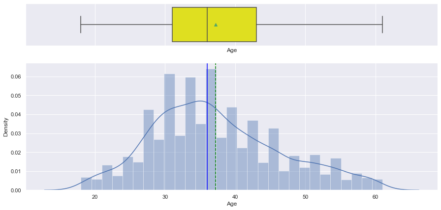

```python
histogram_boxplot(df.Age)
```

### DurationOfPitch

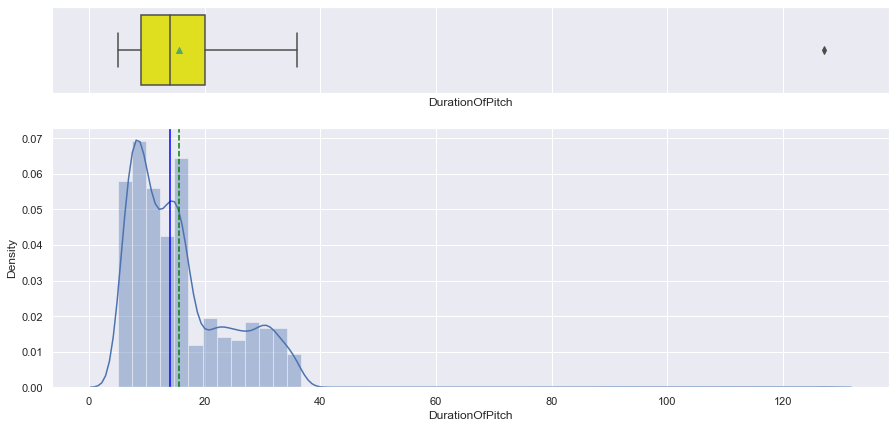

```python
histogram_boxplot(df.DurationOfPitch);
```

```python
df_outliers = outliers('DurationOfPitch')
print("Number of outliers:", df_outliers.shape[0])
df_outliers
```

```
Number of outliers: 1
```

|  | ProdTaken | Age | TypeofContact | CityTier | DurationOfPitch | Occupation | Gender | NumberOfPersonVisiting | NumberOfFollowups | ProductPitched | PreferredPropertyStar | MaritalStatus | NumberOfTrips | Passport | PitchSatisfactionScore | OwnCar | NumberOfChildrenVisiting | Designation | MonthlyIncome |
| --- | --- | --- | --- | --- | --- | --- | --- | --- | --- | --- | --- | --- | --- | --- | --- | --- | --- | --- | --- |
| 3878 | 0 | 53.0 | Company Invited | 3 | 127.0 | Salaried | Male | 3 | 4.0 | Basic | 3.0 | Married | 4.0 | 0 | 1 | 1 | 2.0 | Executive | 22160.0 |

- The DurationOfPitch column has one extreme outlier. We will drop this extreme outlier.

```python
df.drop(df_outliers.index, inplace=True)
df.DurationOfPitch.nlargest()
```

```
2505    36.0
2585    36.0
2643    36.0
2648    36.0
2703    36.0
Name: DurationOfPitch, dtype: float64
```

```python
print(f"There are {df.shape[0]} rows in dataset now.")
```

```
There are 4127 rows in dataset now.
```

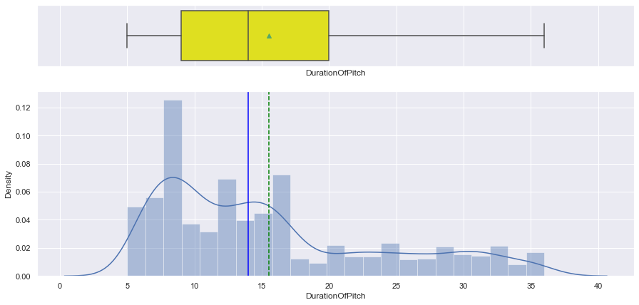

```python
histogram_boxplot(df.DurationOfPitch);
```

### NumberOfTrips

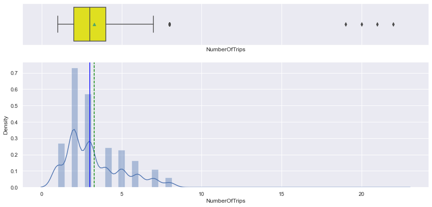

```python
histogram_boxplot(df.NumberOfTrips)
```

```python
df.NumberOfTrips.nlargest()
```

```
3260    22.0
816     21.0
2829    20.0
385     19.0
2446     8.0
Name: NumberOfTrips, dtype: float64
```

```python
df = df[df.NumberOfTrips < 9]
assert df.NumberOfTrips.max() < 9
```

```python
print(f"There are {df.shape[0]} rows in dataset now.")
```

```
There are 4123 rows in dataset now.
```

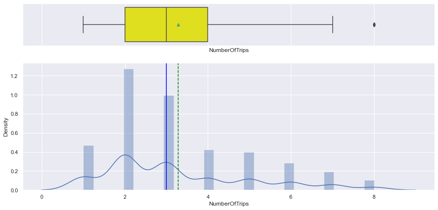

```python
histogram_boxplot(df.NumberOfTrips);
```

### MonthlyIncome

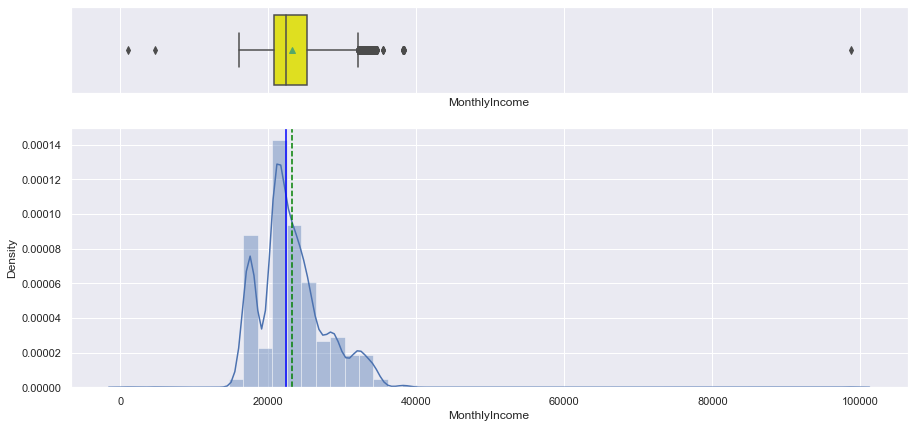

```python
histogram_boxplot(df.MonthlyIncome)
```

```python
print(df.MonthlyIncome.nlargest())
df.MonthlyIncome.nsmallest()
```

```
2482    98678.0
3258    38304.0
4728    38304.0
3573    38291.0
3560    38264.0
Name: MonthlyIncome, dtype: float64
```

```
142      1000.0
2586     4678.0
513     16009.0
1983    16009.0
727     16051.0
Name: MonthlyIncome, dtype: float64
```

### Dropping the extreme outliers in the `MonthlyIncome` column

```python
df = df[df.MonthlyIncome < 40000]
assert df.MonthlyIncome.max() < 40000

df = df[df.MonthlyIncome > 16000]
assert df.MonthlyIncome.min() > 16000
```

```python
print(f"There are {df.shape[0]} rows in dataset now.")
```

```
There are 4120 rows in dataset now.
```

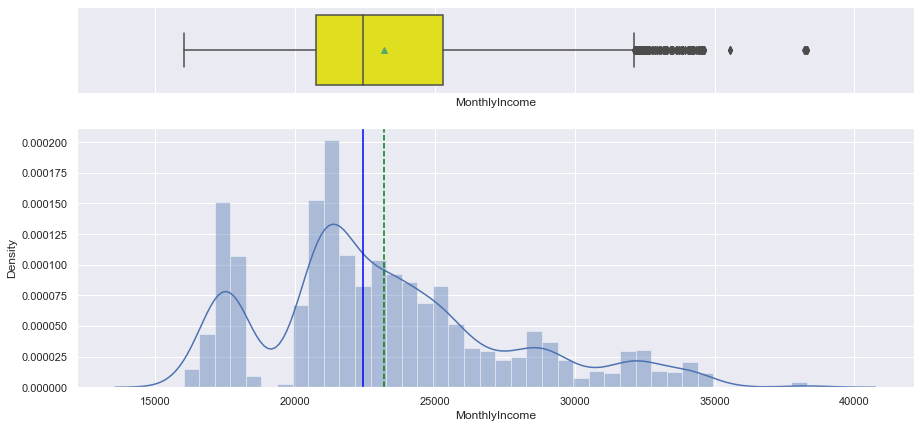

```python
histogram_boxplot(df.MonthlyIncome);
```

### ProdTaken

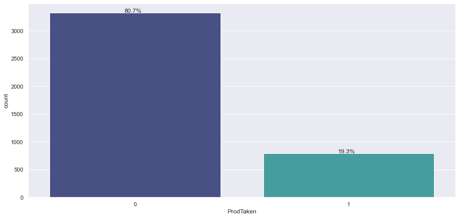

```python
perc_on_bar(df.ProdTaken)
```

- Only 19.3% have taken the product. 81% haven't taken the product.

### TypeOfContact

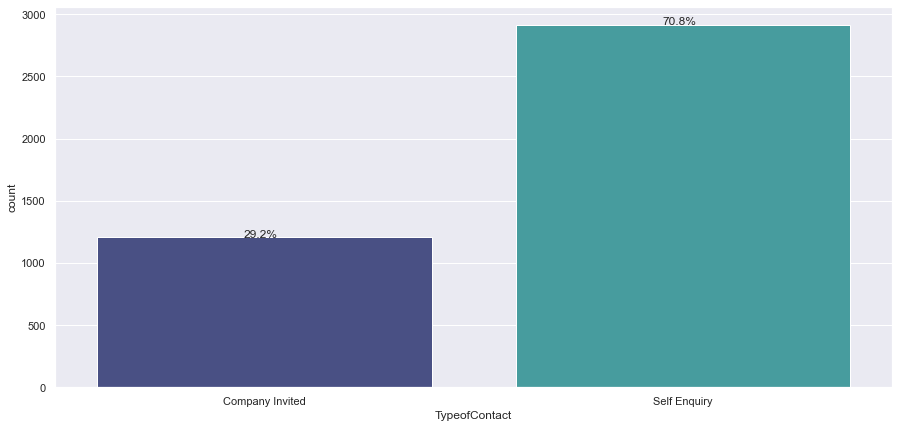

```python
perc_on_bar(df.TypeofContact)
```

### CityTier

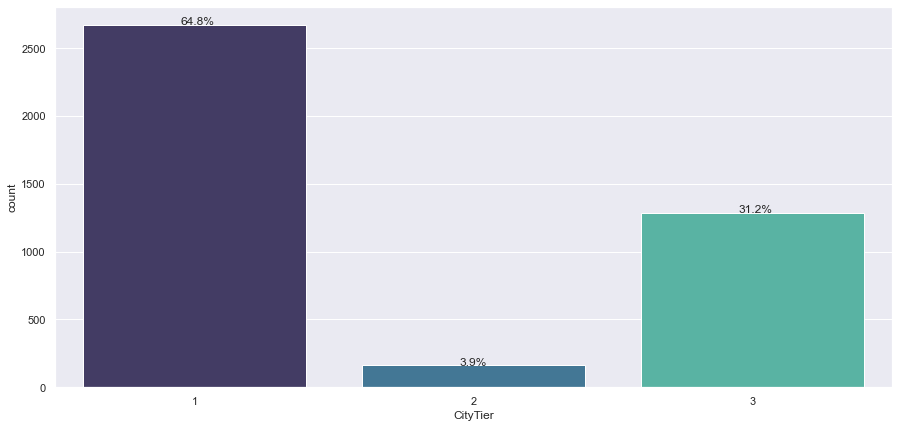

```python
perc_on_bar(df.CityTier)
```

### Occupation

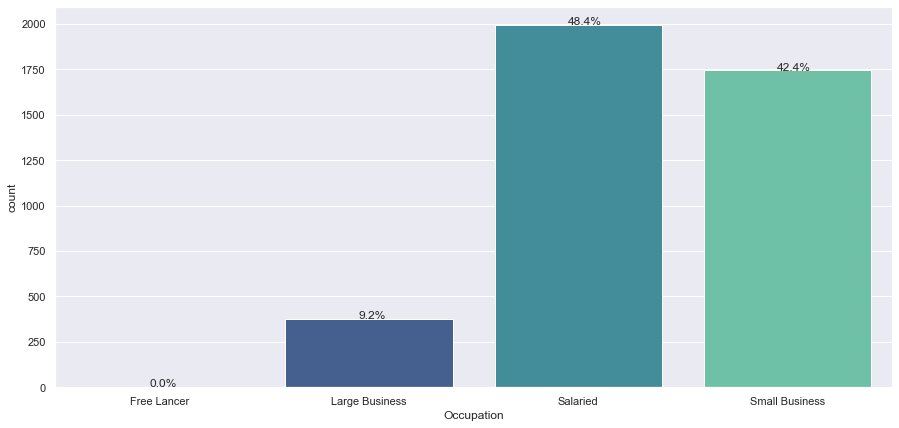

```python
perc_on_bar(df.Occupation)
```

- About 9% Large business, 48% are Salaried and 42.4% are Small business. The majority of the customer occupation are salary or small business. Could be both.

### Gender

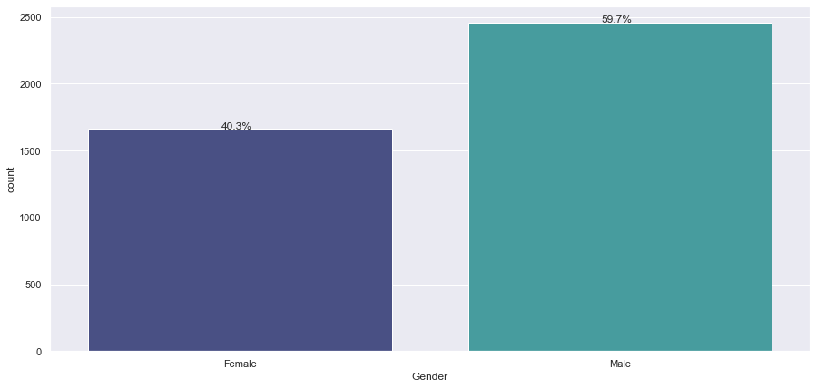

```python
perc_on_bar(df.Gender)
```

- About 60% are Male and 40% are Female.

### NumberOfPersonVisiting

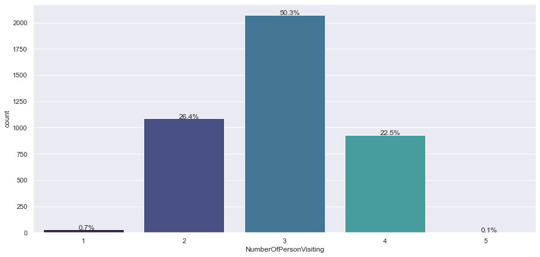

```python
perc_on_bar(df.NumberOfPersonVisiting)
```

- Two people visiting is 26%, three people is 50% and 4 people visiting is 22.5%.

### NumberOfFollowups

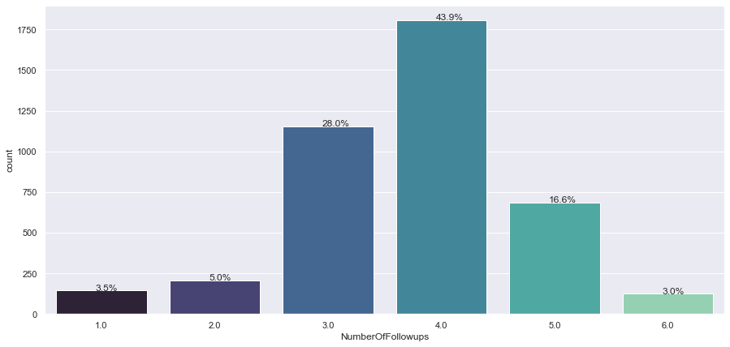

```python
perc_on_bar(df.NumberOfFollowups)
```

- The majority of the number of followups is four with 43.9% of the share. Second is three with 28% of the population.

### ProductPitched

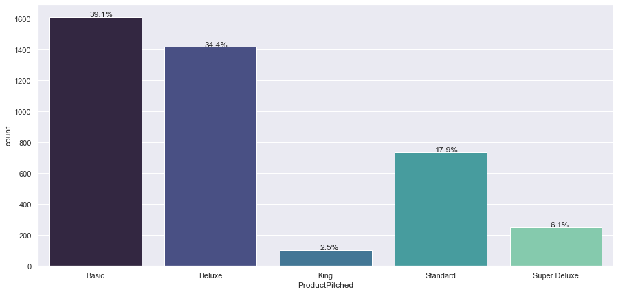

```python
perc_on_bar(df.ProductPitched)
```

- The basic package was pitched 39% of the time. The deluxe package was pitched 34.4% of the time. The standard package come in third and was pitched 17.9% of the time.

### PreferredPropertyStar

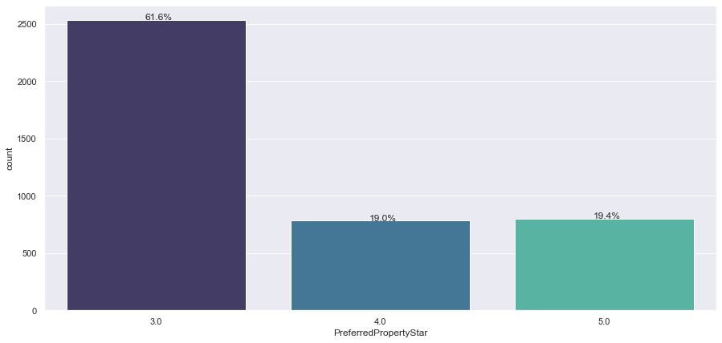

```python
perc_on_bar(df.PreferredPropertyStar)
```

### MaritalStatus

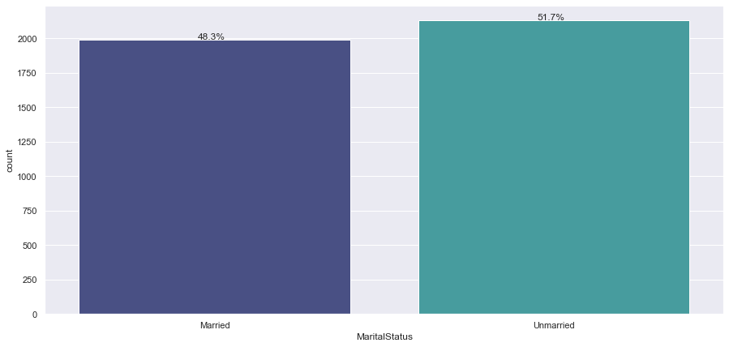

```python
perc_on_bar(df.MaritalStatus)
```

- Unmarried hold the majority of the customer population with 51.7%. Married holds 48.3% of the customer population.

### Passport

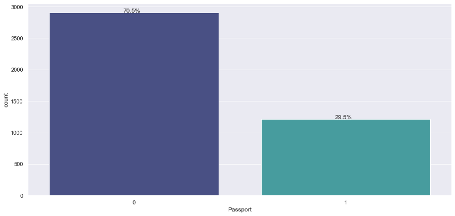

```python
perc_on_bar(df.Passport)
```

- Those customers who dont hold a passport make up the majority at 70.5%. Those with a passport make up 29.5%.

### PitchSatisfactionScore

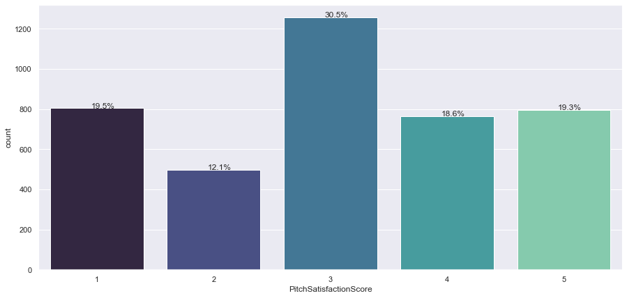

```python
perc_on_bar(df.PitchSatisfactionScore)
```

- A pitch satisfaction score of three makes up the majority with 30.5%. A score of one is the second highest majority at 19.5%. A score of 5 makes up 19.3% and a score of 4 makes up 18.6% of the population.

### OwnCar

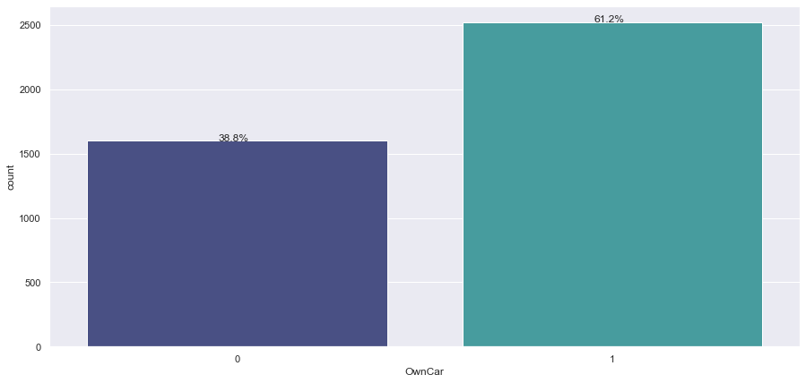

```python
perc_on_bar(df.OwnCar)
```

- Those customers who don't own a car makes up 38.8% of the customer population. Those customer who own a car make up 61.2% of the population.

### NumberOfChildrenVisiting

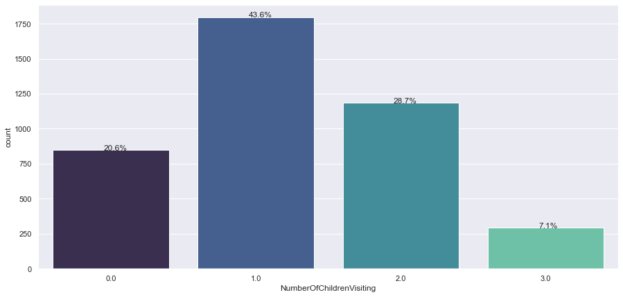

```python
perc_on_bar(df.NumberOfChildrenVisiting)
```

- One child visiting is 43.6%. Two children is 28.7% and zero children is 20.6%. Three children visiting makes up 7.1%.

### Designation

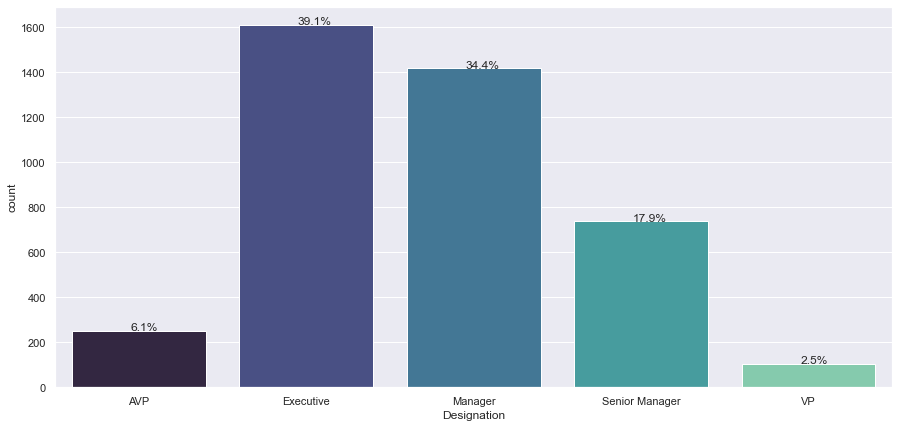

```python
perc_on_bar(df.Designation)
```

- Executives make up the majority with 39.1% of the population. Manager is 34.4%. Senior Manager makes up 17.9%. AVP and VP is 6.1% and 2.5%.

### NumberOfTrips

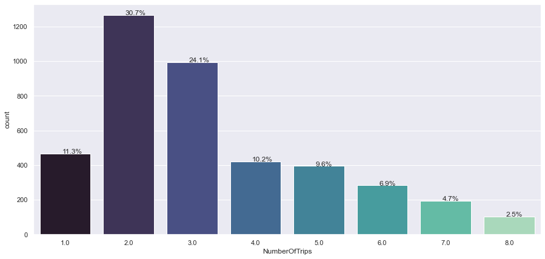

```python
perc_on_bar(df.NumberOfTrips)
```

- The most trips is two, which makes up 30.7% of the population. Second place is three with 24.1%. At third place, is one with 11.3% of the share.

### Bivariate Analysis

```python
## Function to plot stacked bar chart
def stacked_plot(x, y, show_df=True):
    """
    Shows stacked plot from x and y pandas data series
    x: pandas data series
    y: pandas data series
    show_df: flag to show dataframe above plot (default=True)
    """
    if show_df == True:
        info = pd.crosstab(x, y, margins=True)
        info['% - 0'] = round(info[0]/info['All']*100, 2)
        info['% - 1'] = round(info[1]/info['All']*100, 2)
        display(info.sort_values(by='% - 1', ascending=False))

    pd.crosstab(x, y, normalize='index'). plot(kind='bar', stacked=True, figsize=(10,5));
```

```python
def show_boxplots(cols: list, feature: str, show_fliers=True, data=df): #method call to show bloxplots
    """
    Shows boxplots from pandas data series
    cols: list of column names
    feature: dataframe categorical feature
    """
    n_rows = math.ceil(len(cols)/3)
    plt.figure(figsize=(15, n_rows*5))
    for i, variable in enumerate(cols):
        plt.subplot(n_rows, 3, i+1)
        if show_fliers:
            sns.boxplot(data[feature], data[variable], palette="mako", showfliers=True)
        else:
            sns.boxplot(data[feature], data[variable], palette="mako", showfliers=False)
        plt.tight_layout()
        plt.title(variable, fontsize=12)
    plt.show()
```

### Heat map

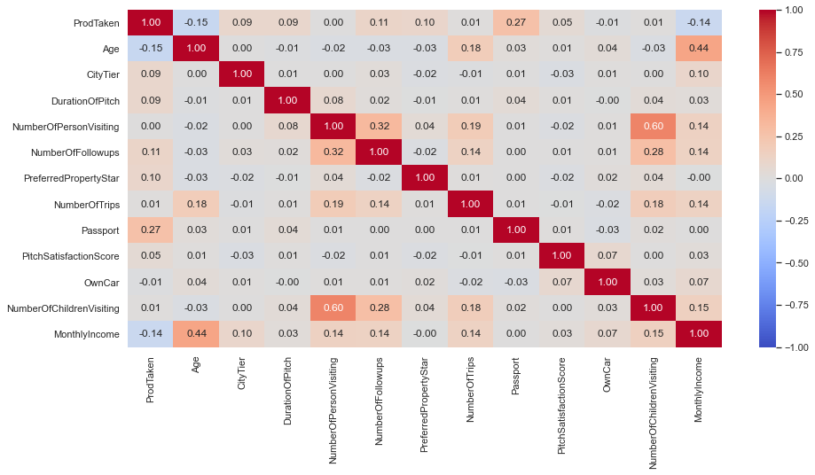

```python
plt.figure(figsize=(15,7))
sns.heatmap(df.corr(),annot=True,vmin=-1,vmax=1,fmt='.2f',cmap='coolwarm');
```

- NumberofChildrenVisiting and NumberOfPersonVisiting are positively correlated.
- Age and MontlyIncome are positively correlated.
- NumberofFollowups and NumberOfPersonVisiting are correlated.

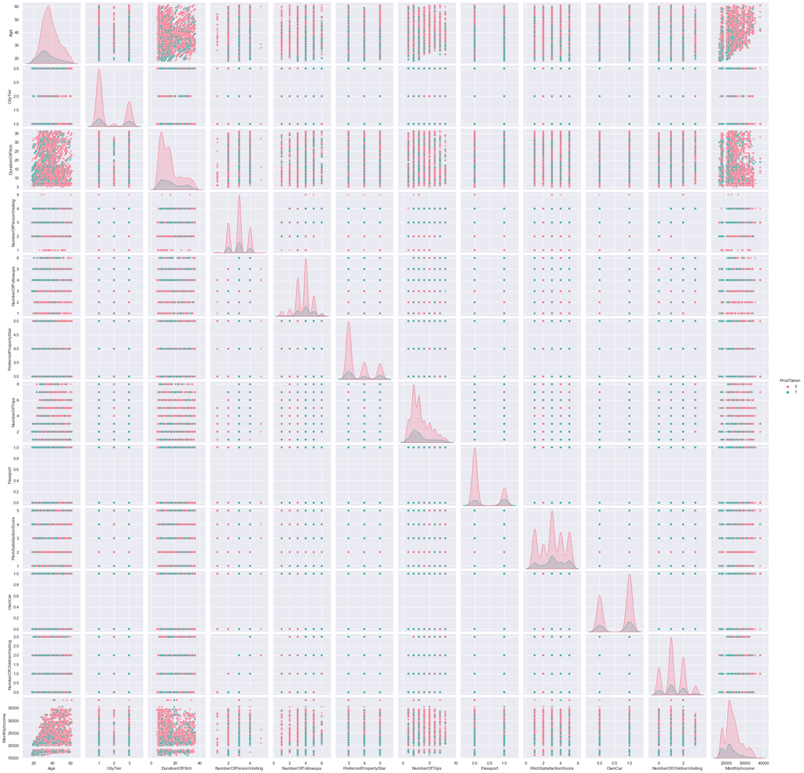

```python
sns.pairplot(data=df,
             vars=['Age', 'CityTier', 'DurationOfPitch',
                   'NumberOfPersonVisiting', 'NumberOfFollowups', 'PreferredPropertyStar',
                   'NumberOfTrips', 'Passport', 'PitchSatisfactionScore', 'OwnCar',
                   'NumberOfChildrenVisiting', 'MonthlyIncome'],
             hue='ProdTaken',
             palette='husl',
             plot_kws={'alpha': 0.5});
```